# Informe dinámico

Álvaro García Muñoz

2024-06-17

# Introducción

En este documento concevido para el análisis de datos normalizados provenientes de protemómica usando tecnología de **Olink**, más concretamente la tecnología *NPX* (Normalized Protein eXpression), de un archivo csv llamado *Olink.NPX_values.Inflammatory-panels.csv*. En el se describen se encuentran muestras de las proteínas de personas que han sufrido enfermedades respiratorias graves, principalmente fibrosis pulmonar idiopática y COVID-19 grave. El script desarrollado en este documento presenta un análisis de este tipo de datos junto a un conjunto de datos de los mimsas muestras con datos sobre los fenotipos de las muestras.

# Exploración de los datos

Para realizar correctamente el estudio multivariante de los datos se debe comenzar por reconocer las variables, es por ello que este primer apartado esta dedicado a la exploración de las variables. Se dividirá en 3 sub-apartados:

- Exploración de datos faltantes.
- Análisis univariante.
- Análisis multivariante.

Antes de comenzar con la exploración de los datos se observa la estructura de ambos conjuntos de datos:

```r
str(proteins[,10])
```

```
##  num [1:432] 3.8248 -0.3947 0.1838 -1.2128 0.0071 ...
```

```r
str(phenotypes)
```

```
## spc_tbl_ [432 × 6] (S3: spec_tbl_df/tbl_df/tbl/data.frame)
##  $ id       : chr [1:432] "S0004" "S0407" "S0429" "S1894" ...
##  $ Diagnosis: num [1:432] 1 1 1 1 1 1 1 2 1 1 ...
##  $ Site     : num [1:432] 1 1 1 1 1 1 1 1 1 1 ...
##  $ Sex      : num [1:432] 1 2 2 1 1 1 1 2 1 1 ...
##  $ Age      : num [1:432] 60 66 68 74 56 65 63 62 66 75 ...
##  $ Ancestry : chr [1:432] "A" "W" "B" "W" ...
##  - attr(*, "spec")=
##   .. cols(
##   ..   id = col_character(),
##   ..   Diagnosis = col_double(),
##   ..   Site = col_double(),
##   ..   Sex = col_double(),
##   ..   Age = col_double(),
##   ..   Ancestry = col_character()
##   .. )
##  - attr(*, "problems")=<externalptr>
```

## Exploración de datos faltantes

```r
m <- 5
temp <- mice(proteins, method = 'pmm', m=m, seed=23, print=FALSE)
```

Una vez realizado el análisis y el cálculo $m = 5$ veces se imputan en los valores en los datos faltantes:

```r
for(i in 1:ncol(proteins)){
  index <- which(is.na(proteins[,i]))
  proteins[index, i] <- median(t(temp$imp[[i]]))
}
```

## Análisis univariante

En este apartado se procede a realizar un análisis profundo sobre las variables estudiadas.

### Proteínas

Se empezará por estudiar las provenientes de proteómica, estas serán variables ya normalizadas. El siguiente plot muestra la densidad de una muestra aleatoria de proteínas:

[figure not shown]

```r
index <- sample(2:ncol(proteins), 16, replace = FALSE)
#Random indexes to plot 16 proteins
temp <- cbind(proteins[,index])

#Density (sample)
pl<- list()
i <- 1
for(x in temp[,1:4]){
  pl[[i]] <- ggplot(temp, aes(x)) +
    geom_density(color = colors[2], fill = colors[1]) +
    labs(title = paste("Density of protein number", colnames(temp)[i]), x = "Proteína",  y = "Densidad") +
    theme_light()
  i <- i+1
}
grid.arrange(pl[[1]], pl[[2]], pl[[3]], pl[[4]], ncol = 2)
```

A continuación, se desea estudiar la desviación de las diferentes variables, por lo que se usará la mediana absoluta de desviación, usaremos una muestra de 16 proteínas para este estudio estudio:

```
## Analysis of variable X284:
## -The quartiles of X284. Min:-0.785. 1Q:-0.116. Median:0.06865. 3Q:0.25035. Máx:1.1466
## -The mean of X284 is 0.081099537037037
## -The median absolute deviation of X284 is 0.27012972
## -The coefficient of variation of X284 is 3.63281648134527
```

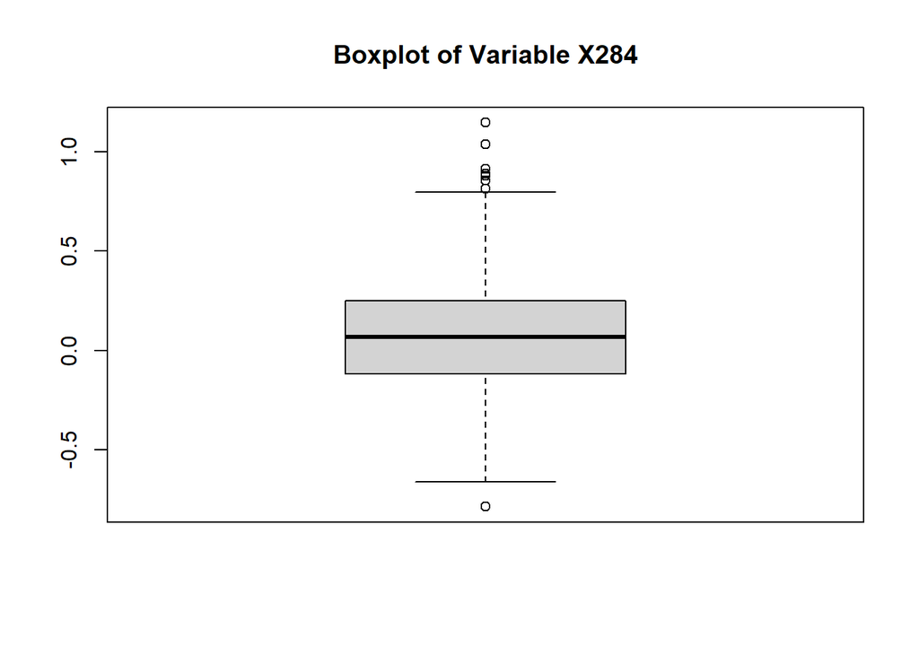

```
## Analysis of variable X248:
## -The quartiles of X248. Min:0.422. 1Q:2.00485. Median:2.33085. 3Q:2.6844. Máx:4.1597
## -The mean of X248 is 2.3440125
## -The median absolute deviation of X248 is 0.4996362
## -The coefficient of variation of X248 is 0.22801565274445
```

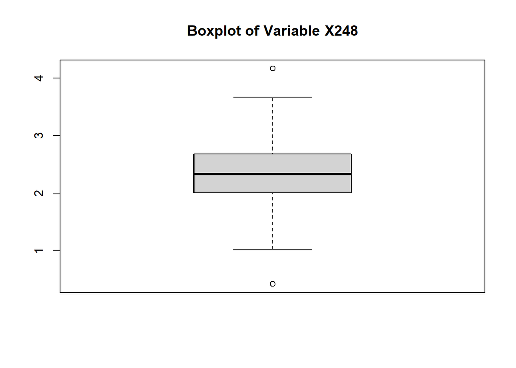

```
## Analysis of variable X121:
## -The quartiles of X121. Min:-1.1069. 1Q:1.5916. Median:2.32005. 3Q:3.07675. Máx:5.8034
## -The mean of X121 is 2.32967175925926
## -The median absolute deviation of X121 is 1.11432216
## -The coefficient of variation of X121 is 0.46486165181251
```

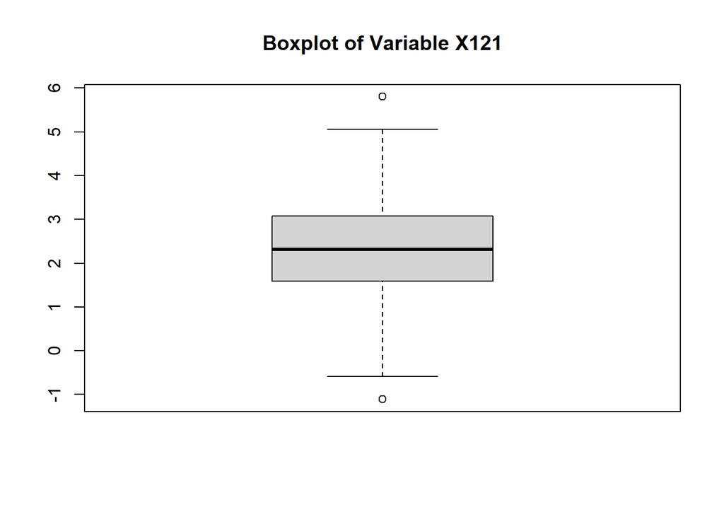

```
## Analysis of variable X171:
## -The quartiles of X171. Min:-0.8902. 1Q:0.24105. Median:0.5737. 3Q:0.8394. Máx:3.0507
## -The mean of X171 is 0.570826388888889
## -The median absolute deviation of X171 is 0.44240784
## -The coefficient of variation of X171 is 0.910861531351233
```

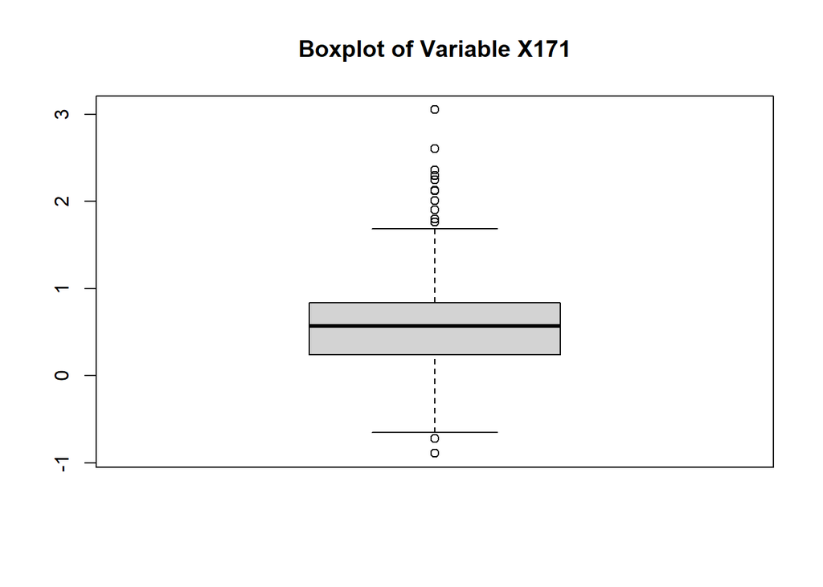

```
## Analysis of variable X103:
## -The quartiles of X103. Min:-0.4923. 1Q:0.7194. Median:1.20935. 3Q:1.8813. Máx:6.7234
## -The mean of X103 is 1.38370138888889
## -The median absolute deviation of X103 is 0.83388837
## -The coefficient of variation of X103 is 0.720040205850526
```

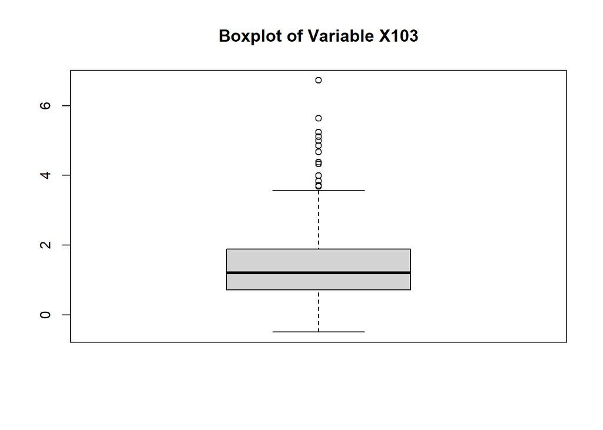

```
## Analysis of variable X301:
## -The quartiles of X301. Min:-0.3178. 1Q:2.2272. Median:3.1409. 3Q:3.98955. Máx:7.7466
## -The mean of X301 is 3.13654259259259
## -The median absolute deviation of X301 is 1.30357605
## -The coefficient of variation of X301 is 0.40933195140652
```

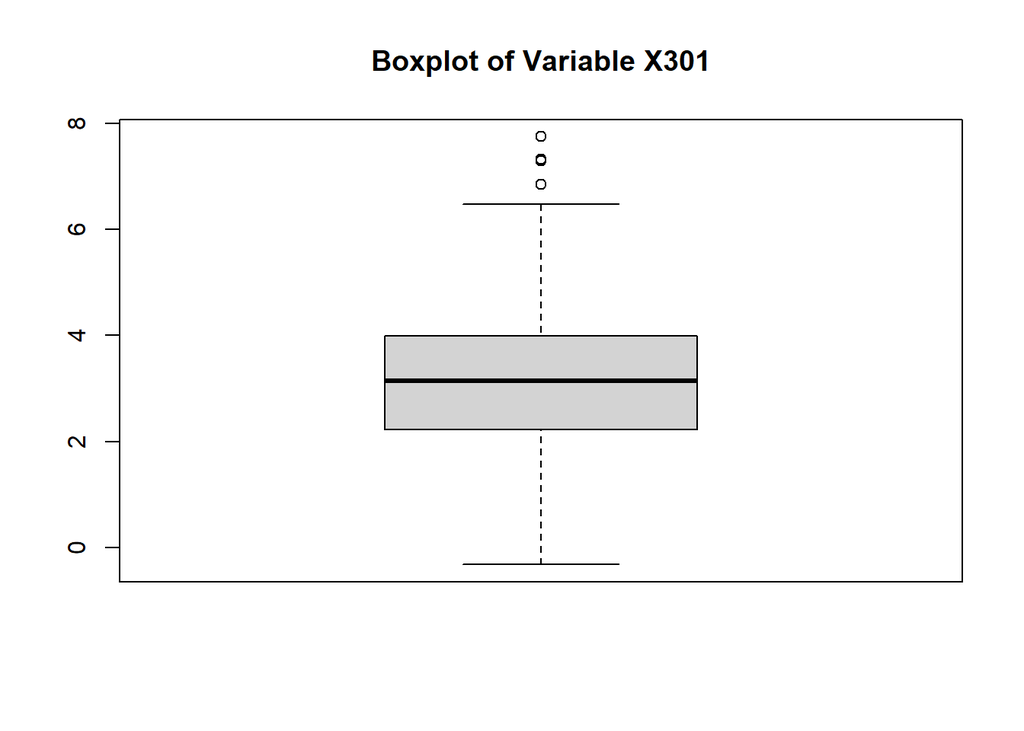

```
## Analysis of variable X290:
## -The quartiles of X290. Min:-1.2336. 1Q:3.503. Median:4.5014. 3Q:5.0127. Máx:5.9338
## -The mean of X290 is 4.17184421296296
## -The median absolute deviation of X290 is 0.92921955
## -The coefficient of variation of X290 is 0.281303583716942
```

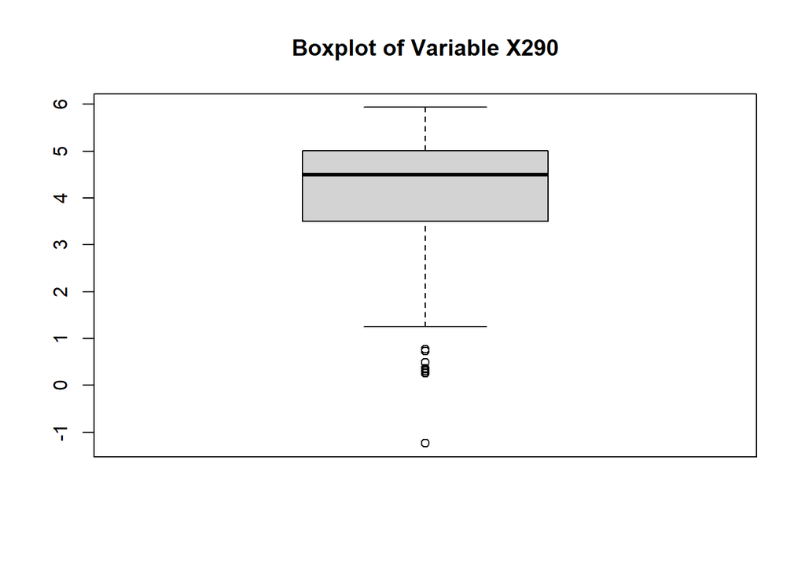

```
## Analysis of variable X149:
## -The quartiles of X149. Min:-0.4003. 1Q:1.0855. Median:1.5451. 3Q:2.1747. Máx:4.8466
## -The mean of X149 is 1.70305833333333
## -The median absolute deviation of X149 is 0.79237557
## -The coefficient of variation of X149 is 0.50336068858925
```

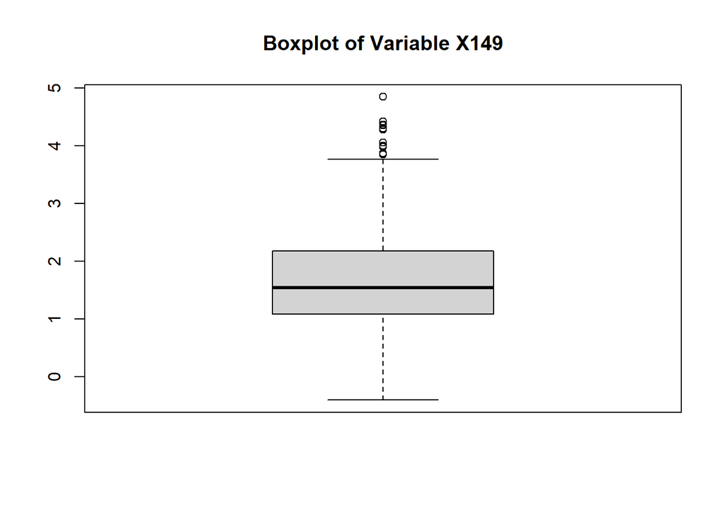

```
## Analysis of variable X145:
## -The quartiles of X145. Min:-0.5589. 1Q:0.5233. Median:0.8223. 3Q:1.11255. Máx:3.4061
## -The mean of X145 is 0.847962037037037
## -The median absolute deviation of X145 is 0.43855308
## -The coefficient of variation of X145 is 0.628415780986793
```

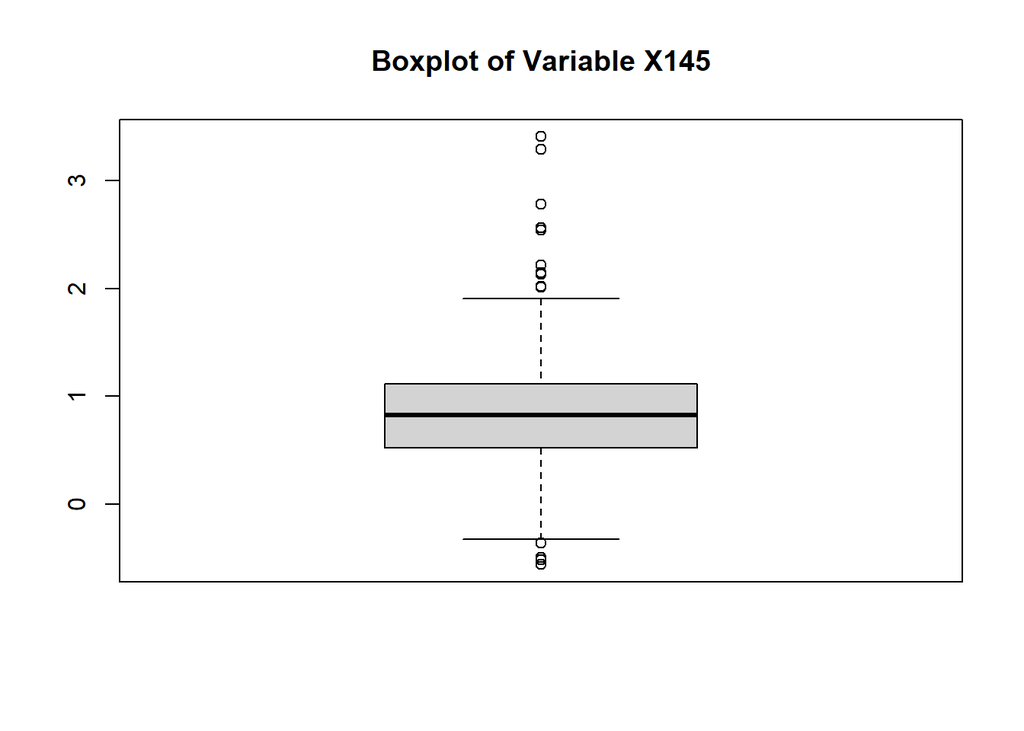

```
## Analysis of variable X164:
## -The quartiles of X164. Min:-0.2483. 1Q:0.53255. Median:0.7648. 3Q:1.02475. Máx:2.3337
## -The mean of X164 is 0.785886111111111
## -The median absolute deviation of X164 is 0.37502367
## -The coefficient of variation of X164 is 0.493886022386847
```

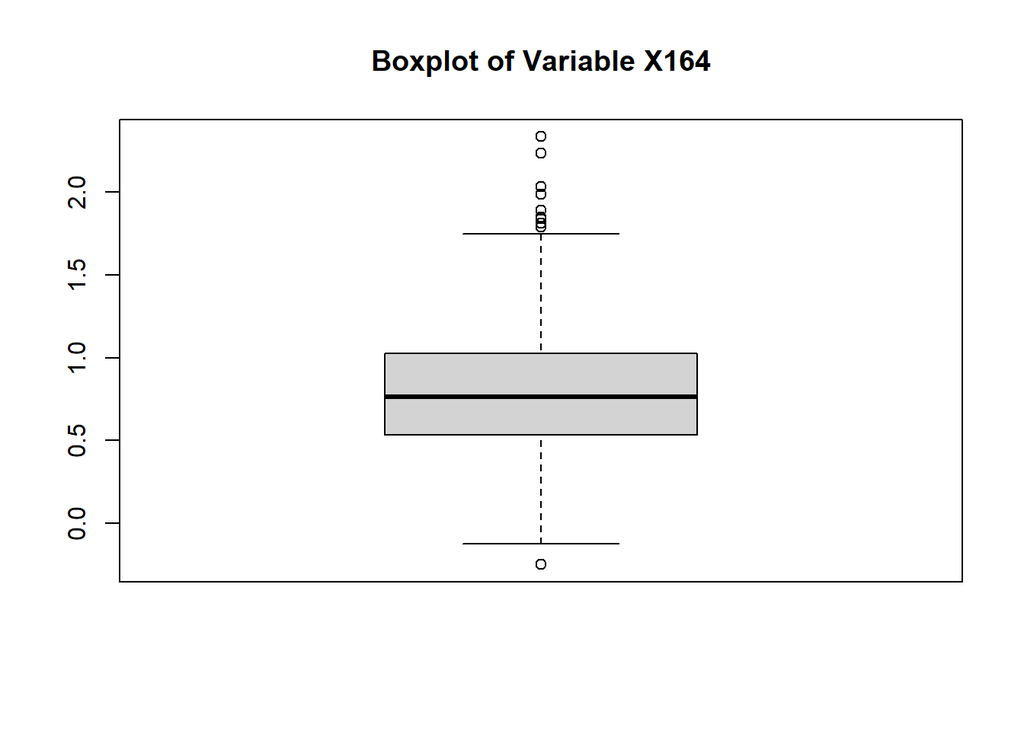

```
## Analysis of variable X326:
## -The quartiles of X326. Min:-0.8051. 1Q:0.2786. Median:0.49895. 3Q:0.7903. Máx:1.6371
## -The mean of X326 is 0.520383333333333
## -The median absolute deviation of X326 is 0.38043516
## -The coefficient of variation of X326 is 0.725004887957151
```

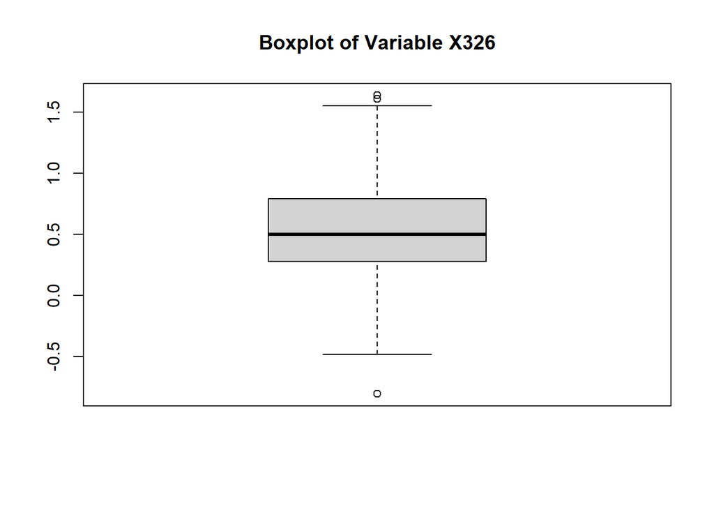

```
## Analysis of variable X198:
## -The quartiles of X198. Min:-1.2834. 1Q:2.04125. Median:3.59905. 3Q:4.70485. Máx:8.3665
## -The mean of X198 is 3.38373240740741
## -The median absolute deviation of X198 is 1.92567501
## -The coefficient of variation of X198 is 0.536396412983744
```

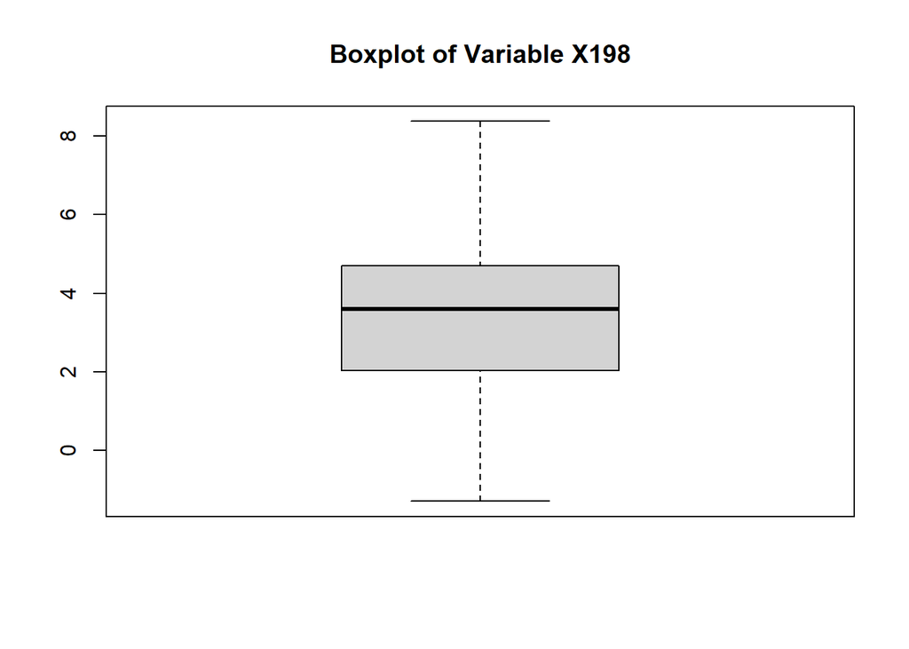

```
## Analysis of variable X31:
## -The quartiles of X31. Min:-1.5384. 1Q:-0.20245. Median:0.0674. 3Q:0.3544. Máx:3.7996
## -The mean of X31 is 0.107448842592593
## -The median absolute deviation of X31 is 0.4129041
## -The coefficient of variation of X31 is 5.04721281930906
```

[4 more figures not shown]

```r
for (i in 1:ncol(temp)){
    tempt <- fivenum(temp[,i])
    q <- paste('-The quartiles of ', colnames(temp)[i],
               '. Min:',tempt[1],
               '. 1Q:' ,tempt[2],
               '. Median:', tempt[3],
               '. 3Q:', tempt[4],
               '. Máx:', tempt[5]
               , sep = '')
    m <- paste('-The mean of', colnames(temp)[i], 'is', mean(temp[,i], sep= ' '))
    mad <- paste("-The median absolute deviation of",colnames(temp)[i], "is", mad(temp[,i]), sep= " ")

    tempt <- sd(temp[,i])/mean(temp[,i])
    cv <- paste("-The coefficient of variation of",colnames(temp)[i], "is", tempt, sep= " ")
    title <- paste('Analysis of variable ', colnames(temp)[i], ':', sep = '')
    cat(title ,q, m, mad, cv, sep = "\n")

    boxplot(temp[,i], main = paste("Boxplot of Variable", colnames(temp)[i], sep = " "))
  }
```

También, se desea analizar la forma de distribución de las diferentes proteínas. Para ello se usarán dos estadísticos, la **curtosis** y el **sesgo**:

```
## Kurtosis lengths:
## Normal:
## 0
## Leptokurtic:
## 329
## Platykurtic:
## 39
```

```
## Skewness lengths:
## Symmetric:
## 0
## Right:
## 0
## Left:
## 368
```

Se constata que las variable son mayormente, *Leptokurtic* y *Left*.

### Fenotipos

Una vez realizado este pequeño análisis univariante de las proteínas se procede a realizar un análisis univariante de los datos fenotípicos. Estan son las variables que fenotípicas que se están estudiando:

*Diagnosis, Site, Sex, Age, Ancestry*.

Se procede a representar las variables:

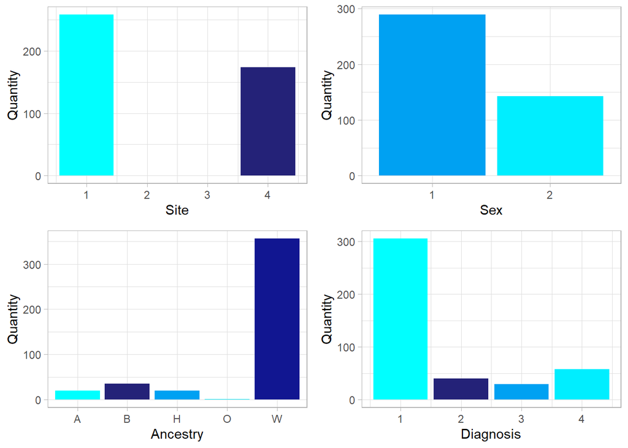

```r
phenotypes$AgeGroup <- cut(phenotypes$Age, seq(0, 100, 10))
phenotypes$Sex <- as.character(phenotypes$Sex)

p1 <- ggplot(phenotypes, aes(x = Site)) + geom_bar(fill = colors[1:2]) + xlab('Site') + ylab('Quantity') + theme_light()
p2 <- ggplot(phenotypes, aes(x = Sex)) + geom_bar(fill = colors[3:4]) + xlab('Sex') + ylab('Quantity') + theme_light()
p3 <- ggplot(phenotypes, aes(x = Ancestry)) + geom_bar(fill = colors[1:5]) + xlab('Ancestry') + ylab('Quantity') + theme_light()
p4 <- ggplot(phenotypes, aes(x = Diagnosis)) + geom_bar(fill = colors[1:4]) + xlab('Diagnosis') + ylab('Quantity') + theme_light()
grid.arrange(p1, p2, p3, p4, ncol = 2)
```

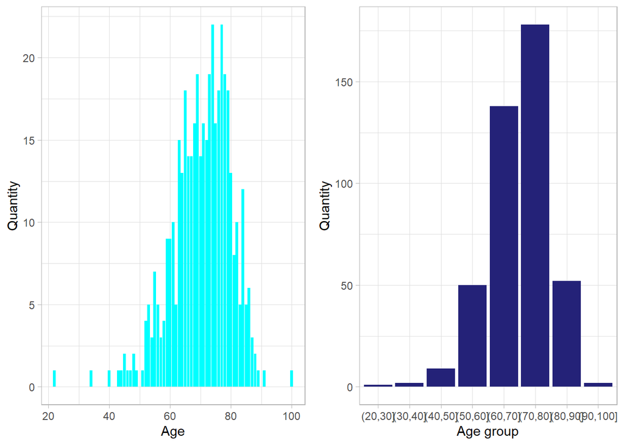

```r
p5 <- ggplot(phenotypes, aes(x = Age)) + geom_bar(fill = colors[1]) + xlab('Age') + ylab('Quantity') + theme_light()
p6 <- ggplot(phenotypes, aes(x = AgeGroup)) + geom_bar(fill=colors[2]) + xlab('Age group') + ylab('Quantity') + theme_light()
grid.arrange(p5, p6, ncol = 2)
```

## Análisis bivariante

A continuación se procede a realizar un estudio bivariado de las diferentes variables a estudiar.

### Modelos lineales

Se estudia la la correlacción de las proteínas con el objetivo de escoger las de mayor correlacción para realizar una regresión lineal:

```r
#Define a threshold for strong correlation
threshold1 <- 0.95
cr <- cor(proteins[,-1])

temp1 <- c()
for(i in 1:ncol(cr)){
  for(j in i:nrow(cr)){
    if(abs(cr[i,j]) > threshold1 && i!=j){
      temp1 <- rbind(temp1, c(i,j))
    }
  }
}

#Define a threshold for weak correlation
threshold2 <- 0.01
cr <- cor(proteins[,-1])
temp2 <- c()
for(i in 1:ncol(cr)){
  for(j in i:nrow(cr)){
    if(abs(cr[i,j]) < threshold2 && i!=j){
      temp2 <- rbind(temp2, c(i,j))
    }
  }
}

temp1.cor <- temp1
temp2.cor <- temp2
```

En total obtenemos 13 pares de proteínas con una alta correlacción. Se procede a mostrar una regresión lineal de una muestra aleatoria de estas proteínas:

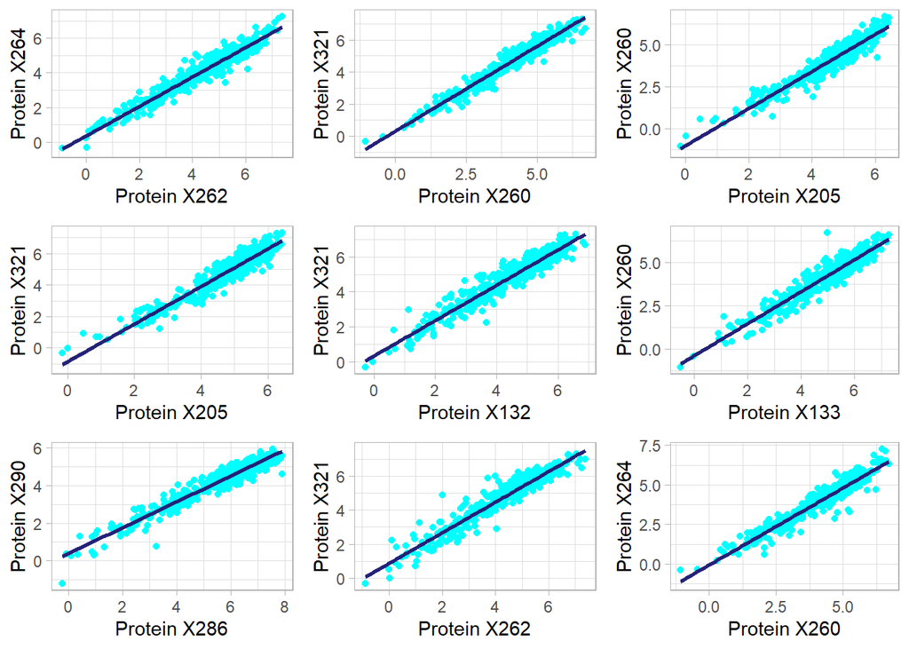

```r
#Linear regression selecting 9 proteins highly and positively correlated
temp <- sample(1:nrow(temp1), 9)
#'temp1' contains the protein indexes
temp1 <- temp1[temp,]
pl <- list()
for(i in 1:nrow(temp1)){
  data <- data.frame("x" =proteins[,temp1[i,1]+1], "y"=proteins[,temp1[i,2]+1])
  pl[[i]] <- ggplot(aes(x, y), data = data) +
    geom_point(color = colors[1])+
    geom_smooth(method = "lm", se = TRUE, color = colors[2])+
    xlab(paste('Protein',colnames(proteins)[temp1[i,1]+1]))+
    ylab(paste('Protein',colnames(proteins)[temp1[i,2]+1]))+
    theme_light()
}
grid.arrange(pl[[1]], pl[[2]], pl[[3]],
             pl[[4]], pl[[5]], pl[[6]],
             pl[[7]], pl[[8]], pl[[9]],
             ncol = 3)
```

### Covarianza proteínas

Se estudia la covarianza de las proteínas

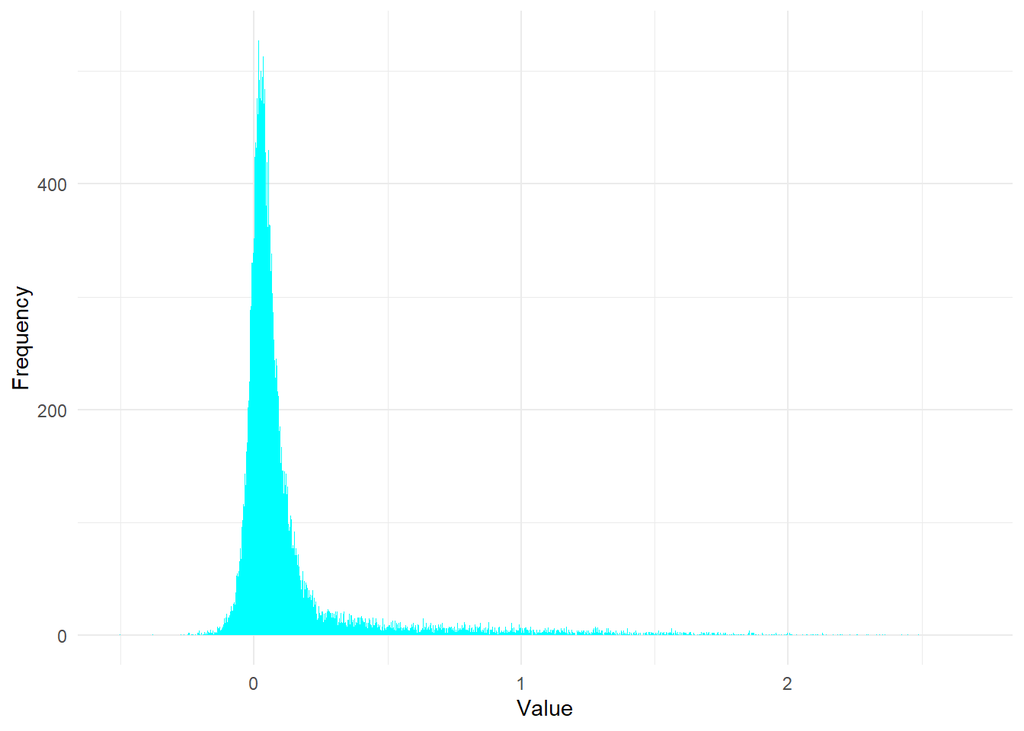

```r
temp <- cov(proteins[,-1])
covariance <- data.frame(x = temp[lower.tri(temp)])

ggplot(covariance, aes(x = x)) +
  geom_histogram(binwidth = 0.001, fill = colors[1]) +
  labs(x = "Value", y = "Frequency") +
  theme_minimal()
```

## Análisis multivariante

### Agrupamiento de los datos

Se ajustan los datos, vamos a transformar la matriz de fenotipos.

```r
phenotypes$Diagnosis <- as.factor(phenotypes$Diagnosis)
phenotypes$Site <- as.factor(phenotypes$Site)
phenotypes$Sex <- as.factor(phenotypes$Sex)
temp <- dummy(phenotypes[,-1], int = TRUE)
temp1 <- cbind('Age' = phenotypes$Age, temp)
phenotypes.int <- cbind(phenotypes[,1], temp1)
phenotypes.int <- phenotypes.int[,-grep('AgeGroup_.', colnames(phenotypes.int))]
```

Una vez ajustada la matriz de fenotipos a una matriz numérica se porcede a combinarla con la matriz de proteínas. Se obtendran 3 matrices sujetas a estudio: - **EM (Extended matrix)**: Esta será la matriz que guardará todos los datos y la principal matriz sometida a estudio

- **Proteins.nb (Proteins new base)**: Esta será la matriz que contendrá la información proteíca de los individuos definida en una base sin covarianza entre los individuos.
- **Data**_: Esta será una matriz sin la variable *Diagnosis* utilizada para los agrupamientos supervisados.

```r
labels <- subset(phenotypes, select = c(id, Diagnosis))
proteins.nb <- proteins[,-temp1.cor[,1]]
rownames(proteins.nb) <- proteins.nb$id

em <- merge(proteins.nb, phenotypes.int, by='id')


proteins.nb <-scale(proteins.nb[,-which(colnames(proteins.nb) == "id")])
em <- scale(em[,-1])

data <- em[,-grep('Diagnosis',colnames(em))]
rownames(data) <- rownames(em)
data <- scale(data[,-1])

write.csv2(proteins.nb, "proteins-matrix.csv", quote = FALSE, row.names = FALSE)
write_tsv(phenotypes.int, "phenotypes-matrix.tsv", quote = "none")
```

### Detección de valores atípicos

Se procede a calcular estimadores robustos de la matriz de proteínas y calcular la distancia de Mahalanobis al vector media.

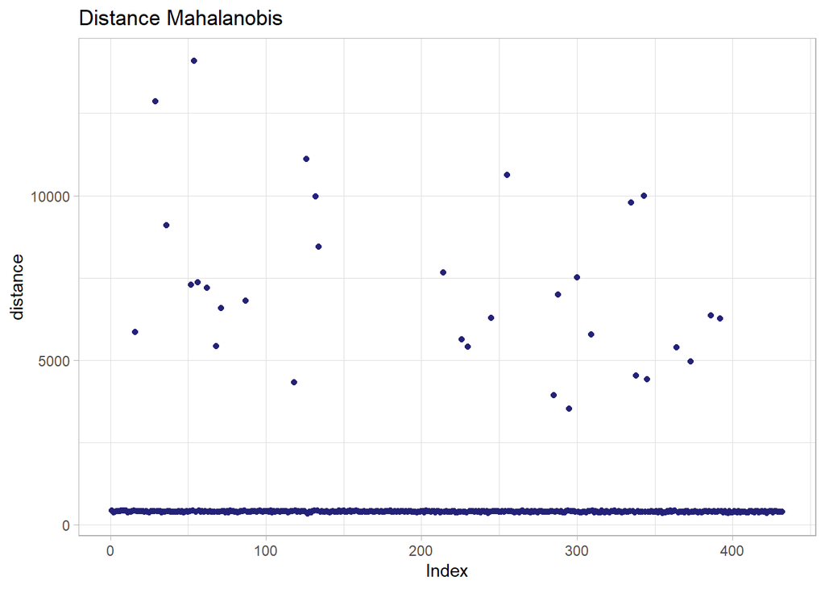

```r
mu <- c()
for (i in 2:ncol(proteins)){
  temp <- rlm(proteins[,i]~1, maxit = 100)$coefficients
  mu <- cbind(mu ,temp)
}

#Robust covariance matrix
sig <- cov.rob(proteins[,-1])$cov

#Distance to mu (Mahalanobis)
dist.mu <- apply(proteins[,-1], 1, function(x) mahalanobis(x, mu, sig))
dist.mu <- data.frame(Index = 1:length(dist.mu), distance = dist.mu)

ggplot(dist.mu, aes(Index, distance)) +
  geom_point(col = colors[2]) +
  theme_light()+
  ggtitle('Distance Mahalanobis')
```

Una vez se ha calculado la distancia de Mahalanobis se define un umbral a a partir del cual se definirá valor atípico, el umbral empleado en este estudio es de 5764.6052449.

```r
#Outlier detection
threshold3 <- 3 * sd(dist.mu$distance)
outlier <- which(dist.mu$distance > threshold3)

#Outlier factor
outlier.v <- rep(0, nrow(proteins))
outlier.v[outlier] <- 1
outlier.v <- factor(outlier.v)
levels(outlier.v) <- c('Normal', 'Outlier')
```

# Distancias

En este punto se procede a realizar un estudio usando el escalado dimensional con la definición de diferentes distancias que permitan visualizar las diferencias entre grupos. Es remarcable decir que las métricas usadas no serán equivalentes puesto permitirá encontrar escalados variados.

## Distancia Euclidea

Se comenzará por estudiar mediante la distancia clásica por excelencia, la distancia euclidea. Calculamos la matriz de distancia euclídea entre los individuos:

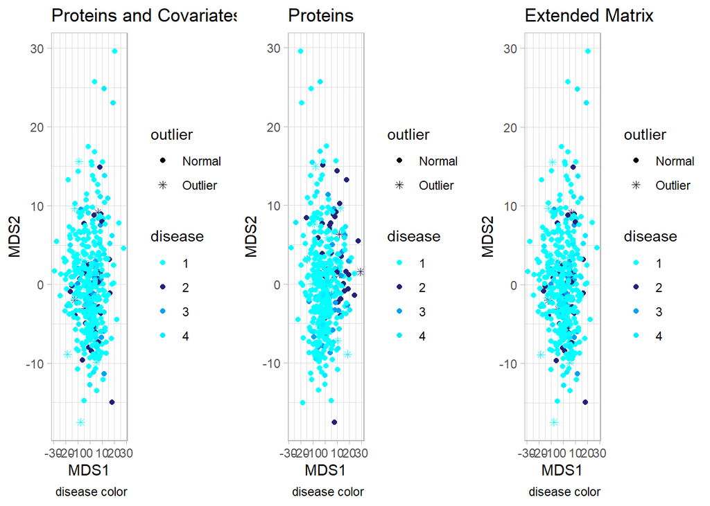

```r
dist.prot.nb <- dist(proteins.nb)
dist.em <- dist(em)
dist.data <- dist(data)

data.mds <-data.frame(X1 = cmdscale(dist.data)[,1], X2 = cmdscale(dist.data)[,2], disease = phenotypes$Diagnosis, outlier = outlier.v)
proteins.mds <- data.frame(X1 = cmdscale(dist.prot.nb)[,1], X2 = cmdscale(dist.prot.nb)[,2], disease = phenotypes$Diagnosis , outlier = outlier.v)
em.mds <-data.frame(X1 = cmdscale(dist.em)[,1], X2 = cmdscale(dist.em)[,2], disease = phenotypes$Diagnosis, outlier = outlier.v)

dise.data.mds <- ggplot(data.mds, aes(X1, X2, col = disease, shape = outlier )) +
  geom_point() +
  labs(title='Proteins and Covariates',
       caption= 'disease color') +
  xlab('MDS1') + ylab('MDS2') +
  theme_light() +
  scale_shape_manual(values = c('Normal' = 19, 'Outlier' = 8)) +
  scale_color_manual(values = colors[1:4])


dise.proteins.mds <- ggplot(proteins.mds, aes(X1, X2, col = disease, shape = outlier )) +
  geom_point() +
  labs(title='Proteins',
       caption= 'disease color') +
  xlab('MDS1') + ylab('MDS2') +
  theme_light() +
  scale_shape_manual(values = c('Normal' = 19, 'Outlier' = 8)) +
  scale_color_manual(values = colors[1:4])

dise.em.mds <-ggplot(em.mds, aes(X1, X2, col = disease, shape = outlier )) +
  geom_point() +
  labs(title='Extended Matrix',
       caption= 'disease color') +
  xlab('MDS1') + ylab('MDS2') +
  theme_light() +
  scale_shape_manual(values = c('Normal' = 19, 'Outlier' = 8)) +
  scale_color_manual(values = colors[1:4])

grid.arrange(dise.data.mds, dise.proteins.mds, dise.em.mds, ncol = 3)
```

## Distancia Pearson

De forma análogica se observa el MDS utilizando la distancia de Pearson de fórmula $d(x,y) = 1-cor(x,y))$.

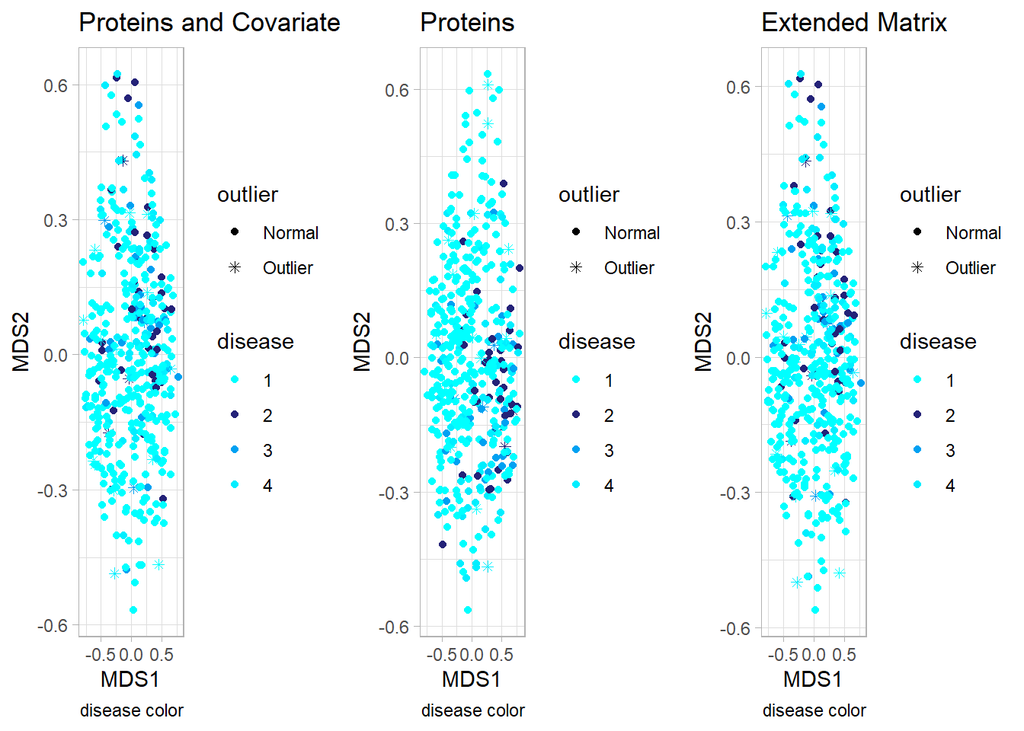

```r
dist.prot.nb <- 1 - cor(t(proteins.nb))
dist.em <-1 - cor(t(em))
dist.data <-1 - cor(t(data))

data.mds <-data.frame(X1 = cmdscale(dist.data)[,1], X2 = cmdscale(dist.data)[,2], disease = phenotypes$Diagnosis, outlier = outlier.v)
proteins.mds <- data.frame(X1 = cmdscale(dist.prot.nb)[,1], X2 = cmdscale(dist.prot.nb)[,2], disease = phenotypes$Diagnosis , outlier = outlier.v)
em.mds <-data.frame(X1 = cmdscale(dist.em)[,1], X2 = cmdscale(dist.em)[,2], disease = phenotypes$Diagnosis, outlier = outlier.v)

dise.data.mds <- ggplot(data.mds, aes(X1, X2, col = disease, shape = outlier )) +
  geom_point() +
  labs(title='Proteins and Covariates',
       caption= 'disease color') +
  xlab('MDS1') + ylab('MDS2') +
  theme_light() +
  scale_shape_manual(values = c('Normal' = 19, 'Outlier' = 8)) +
  scale_color_manual(values = colors[1:4])


dise.proteins.mds <- ggplot(proteins.mds, aes(X1, X2, col = disease, shape = outlier )) +
  geom_point() +
  labs(title='Proteins',
       caption= 'disease color') +
  xlab('MDS1') + ylab('MDS2') +
  theme_light() +
  scale_shape_manual(values = c('Normal' = 19, 'Outlier' = 8)) +
  scale_color_manual(values = colors[1:4])

dise.em.mds <-ggplot(em.mds, aes(X1, X2, col = disease, shape = outlier )) +
  geom_point() +
  labs(title='Extended Matrix',
       caption= 'disease color') +
  xlab('MDS1') + ylab('MDS2') +
  theme_light() +
  scale_shape_manual(values = c('Normal' = 19, 'Outlier' = 8)) +
  scale_color_manual(values = colors[1:4])

grid.arrange(dise.data.mds, dise.proteins.mds, dise.em.mds, ncol = 3)
```

Justamente estas la definición de estas dos métricas es interesante ya que no son métricas equivalentes.

## Distancia Canberra

A continuación, se procede a mostrar el MDS de una métrica equivalente a la euclídea.

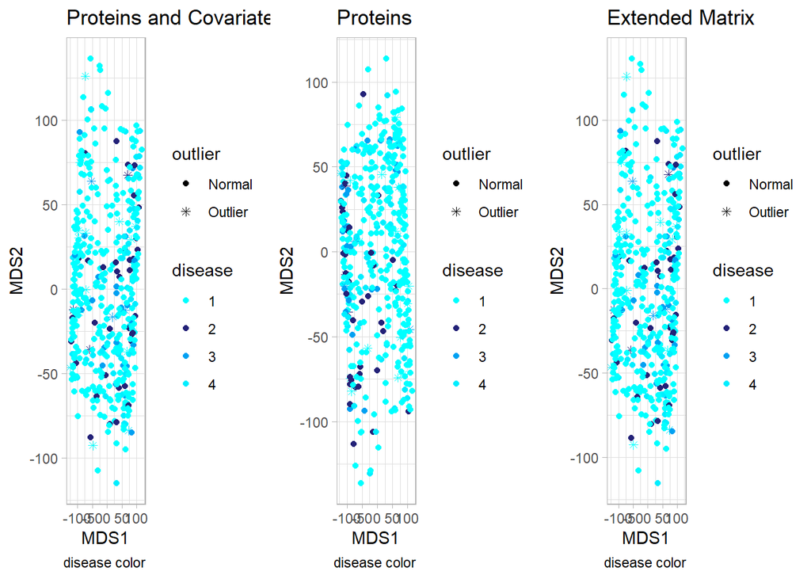

```r
dist.prot.nb <- dist(proteins.nb, method = 'canberra')
dist.em <- dist(em, method = 'canberra' )
dist.data <- dist(data, method = 'canberra')

data.mds <-data.frame(X1 = cmdscale(dist.data)[,1], X2 = cmdscale(dist.data)[,2], disease = phenotypes$Diagnosis, outlier = outlier.v)
proteins.mds <- data.frame(X1 = cmdscale(dist.prot.nb)[,1], X2 = cmdscale(dist.prot.nb)[,2], disease = phenotypes$Diagnosis , outlier = outlier.v)
em.mds <-data.frame(X1 = cmdscale(dist.em)[,1], X2 = cmdscale(dist.em)[,2], disease = phenotypes$Diagnosis, outlier = outlier.v)

dise.data.mds <- ggplot(data.mds, aes(X1, X2, col = disease, shape = outlier )) +
  geom_point() +
  labs(title='Proteins and Covariates',
       caption= 'disease color') +
  xlab('MDS1') + ylab('MDS2') +
  theme_light() +
  scale_shape_manual(values = c('Normal' = 19, 'Outlier' = 8)) +
  scale_color_manual(values = colors[1:4])


dise.proteins.mds <- ggplot(proteins.mds, aes(X1, X2, col = disease, shape = outlier )) +
  geom_point() +
  labs(title='Proteins',
       caption= 'disease color') +
  xlab('MDS1') + ylab('MDS2') +
  theme_light() +
  scale_shape_manual(values = c('Normal' = 19, 'Outlier' = 8)) +
  scale_color_manual(values = colors[1:4])

dise.em.mds <-ggplot(em.mds, aes(X1, X2, col = disease, shape = outlier )) +
  geom_point() +
  labs(title='Extended Matrix',
       caption= 'disease color') +
  xlab('MDS1') + ylab('MDS2') +
  theme_light() +
  scale_shape_manual(values = c('Normal' = 19, 'Outlier' = 8)) +
  scale_color_manual(values = colors[1:4])

grid.arrange(dise.data.mds, dise.proteins.mds, dise.em.mds, ncol = 3)
```

Estas gráficas son los escalados multidimensionales de de diferentes distancias que pueden mostrar agrupamientos de las diferentes variables.

# Clustering methods

En este apartado se utilizaran una serie de métodos para encontrar agrupamientos siguiendo diferentes algoritmos y se mostrarán usando métodos de reducciónd de dimensiones. Los algoritmos de agrupamiento que se utilizarán son:

- K-means.
- HDBScan.

Y los métodos de reducción de dimensiones que se utilizarán son:

- UMAP.
- t-SNE.

## Reducción de dimensiones

Se procede a calcular las coordenadas de ambos métodos de reducción de dimensiones.

### UMAP

Se usa UMAP para la reducción de dimensiones.

```r
em.umap <-umap(em)
data.umap <-umap(data)
proteins.umap <- umap(proteins.nb)
```

Se observan los resultados.

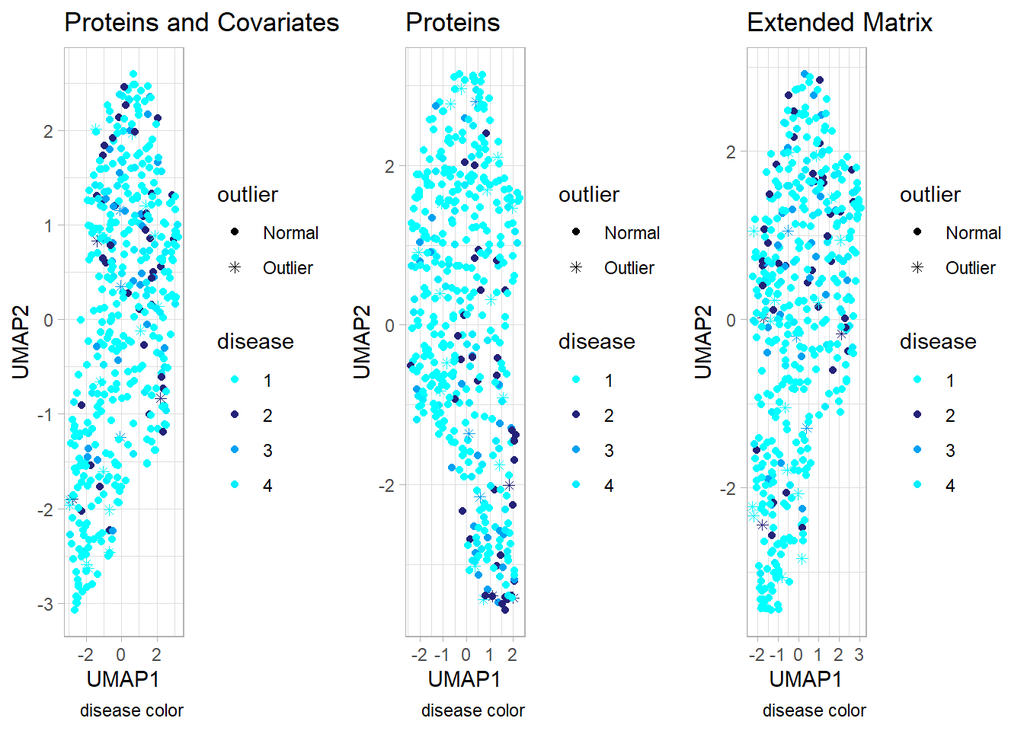

```r
data.umap <-data.frame(data.umap$layout, disease = phenotypes$Diagnosis, outlier = outlier.v)
proteins.umap <- data.frame(proteins.umap$layout, disease = phenotypes$Diagnosis, outlier = outlier.v)
em.umap <- data.frame(em.umap$layout, disease = phenotypes$Diagnosis, outlier = outlier.v)

dise.data.umap <- ggplot(data.umap, aes(X1, X2, col = disease, shape = outlier )) +
  geom_point() +
  labs(title='Proteins and Covariates',
       caption= 'disease color') +
  xlab('UMAP1') + ylab('UMAP2') +
  theme_light() +
  scale_shape_manual(values = c('Normal' = 19, 'Outlier' = 8)) +
  scale_color_manual(values = colors[1:4])


dise.proteins.umap <- ggplot(proteins.umap, aes(X1, X2, col = disease, shape = outlier )) +
  geom_point() +
  labs(title='Proteins',
       caption= 'disease color') +
  xlab('UMAP1') + ylab('UMAP2') +
  theme_light() +
  scale_shape_manual(values = c('Normal' = 19, 'Outlier' = 8)) +
  scale_color_manual(values = colors[1:4])

dise.em.umap <- ggplot(em.umap, aes(X1, X2, col = disease, shape = outlier )) +
  geom_point() +
  labs(title='Extended Matrix',
       caption= 'disease color') +
  xlab('UMAP1') + ylab('UMAP2') +
  theme_light() +
  scale_shape_manual(values = c('Normal' = 19, 'Outlier' = 8)) +
  scale_color_manual(values = colors[1:4])

grid.arrange(dise.data.umap, dise.proteins.umap, dise.em.umap, ncol = 3)
```

### T-SNE

Se usa t-SNE para la reducción de dimensiones.

```r
em.tsne <- Rtsne(em)
data.tsne <- Rtsne(data)
proteins.tsne <- Rtsne(proteins.nb)
```

Se muestrán los resultados:

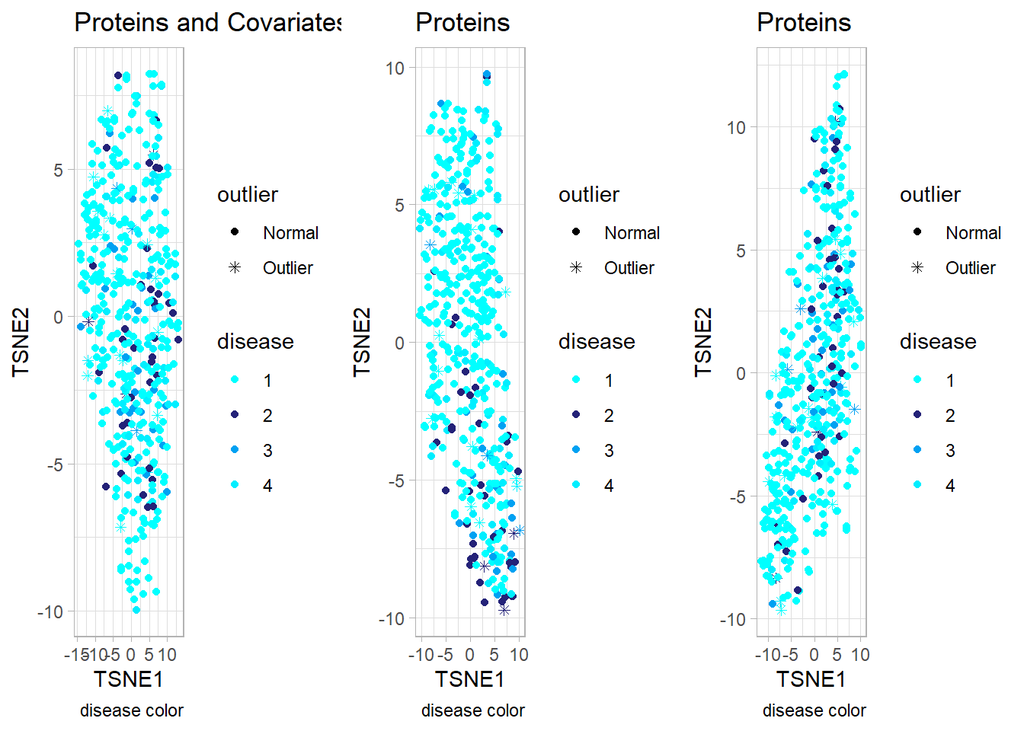

```r
data.tsne <-data.frame(X1 = data.tsne$Y[,1], X2 = data.tsne$Y[,2], disease = phenotypes$Diagnosis, outlier = outlier.v)
proteins.tsne <- data.frame(X1 = proteins.tsne$Y[,1], X2 = proteins.tsne$Y[,2], disease = phenotypes$Diagnosis , outlier = outlier.v)
em.tsne <- data.frame(X1 = em.tsne$Y[,1], X2 = em.tsne$Y[,2], disease = phenotypes$Diagnosis , outlier = outlier.v)

dise.data.tsne <- ggplot(data.tsne, aes(X1, X2, col = disease, shape = outlier )) +
  geom_point() +
  labs(title='Proteins and Covariates',
       caption= 'disease color') +
  xlab('TSNE1') + ylab('TSNE2') +
  theme_light() +
  scale_shape_manual(values = c('Normal' = 19, 'Outlier' = 8)) +
  scale_color_manual(values = colors[1:4])


dise.proteins.tsne <- ggplot(proteins.tsne, aes(X1, X2, col = disease, shape = outlier )) +
  geom_point() +
  labs(title='Proteins',
       caption= 'disease color') +
  xlab('TSNE1') + ylab('TSNE2') +
  theme_light() +
  scale_shape_manual(values = c('Normal' = 19, 'Outlier' = 8)) +
  scale_color_manual(values = colors[1:4])

dise.em.tsne <- ggplot(em.tsne, aes(X1, X2, col = disease, shape = outlier )) +
  geom_point() +
  labs(title='Proteins',
       caption= 'disease color') +
  xlab('TSNE1') + ylab('TSNE2') +
  theme_light() +
  scale_shape_manual(values = c('Normal' = 19, 'Outlier' = 8)) +
  scale_color_manual(values = colors[1:4])

grid.arrange(dise.data.tsne, dise.proteins.tsne, dise.em.tsne, ncol = 3)
```

## Agrupamientos no supervisados

Se procede a realizar agrupamientos no supervisados.

### K-means

Se procede a realizar el agrupamiento usando k-means.

```r
k = 6 #Ajustar según los agrupamientos observados
em.kmeans <-cbind(em.umap, cluster = as.factor(kmeans(em, centers = k)$cluster))
data.kmeans <-cbind(data.umap, cluster = as.factor(kmeans(data, centers = k)$cluster))
proteins.kmeans <-cbind(proteins.umap, cluster =  as.factor(kmeans(proteins.nb, centers = k)$cluster))
```

Se muestrán los resultados usando UMAP.

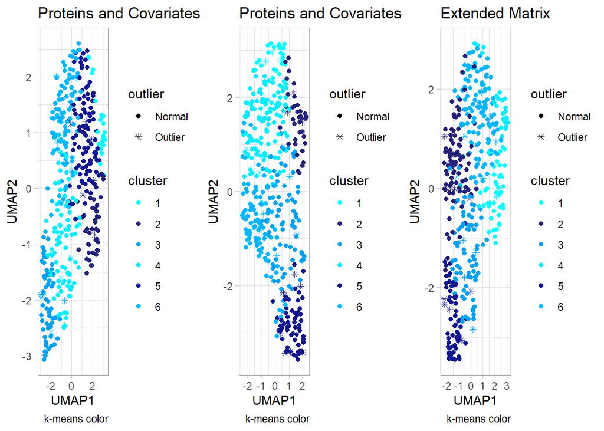

```r
km.data.umap <- ggplot(data.kmeans, aes(X1, X2, col = cluster, shape = outlier )) +
  geom_point() +
  labs(title='Proteins and Covariates',
       caption= 'k-means color') +
  xlab('UMAP1') + ylab('UMAP2') +
  theme_light() +
  scale_shape_manual(values = c('Normal' = 19, 'Outlier' = 8)) +
  scale_color_manual(values = colors[1:k])

km.em.umap <- ggplot(em.kmeans, aes(X1, X2, col = cluster, shape = outlier )) +
  geom_point() +
  labs(title='Extended Matrix',
       caption= 'k-means color') +
  xlab('UMAP1') + ylab('UMAP2') +
  theme_light() +
  scale_shape_manual(values = c('Normal' = 19, 'Outlier' = 8)) +
  scale_color_manual(values = colors[1:k])

km.proteins.umap <- ggplot(proteins.kmeans, aes(X1, X2, col = cluster, shape = outlier )) +
  geom_point() +
  labs(title='Proteins and Covariates',
       caption= 'k-means color') +
  xlab('UMAP1') + ylab('UMAP2') +
  theme_light() +
  scale_shape_manual(values = c('Normal' = 19, 'Outlier' = 8)) +
  scale_color_manual(values = colors[1:k])

grid.arrange(km.data.umap, km.proteins.umap, km.em.umap, ncol = 3)
```

### HDBScan

Se procede a realizar el agrupamiento de las tres matrices usando HDBScan.

```r
  pts = 5 #Ajustar para diferentes resultados
  em.hdbscan <-cbind(em.umap, cluster.hdb = as.factor(hdbscan(em, minPts = pts)$cluster))
  data.hdbscan <-cbind(data.umap, cluster.hdb = as.factor(hdbscan(data, minPts = pts)$cluster))
  proteins.hdbscan <-cbind(proteins.umap, cluster.hdb =  as.factor(hdbscan(proteins.nb, minPts = pts)$cluster))
```

Se muestrán los resultados del agrupamiento usando UMAP.

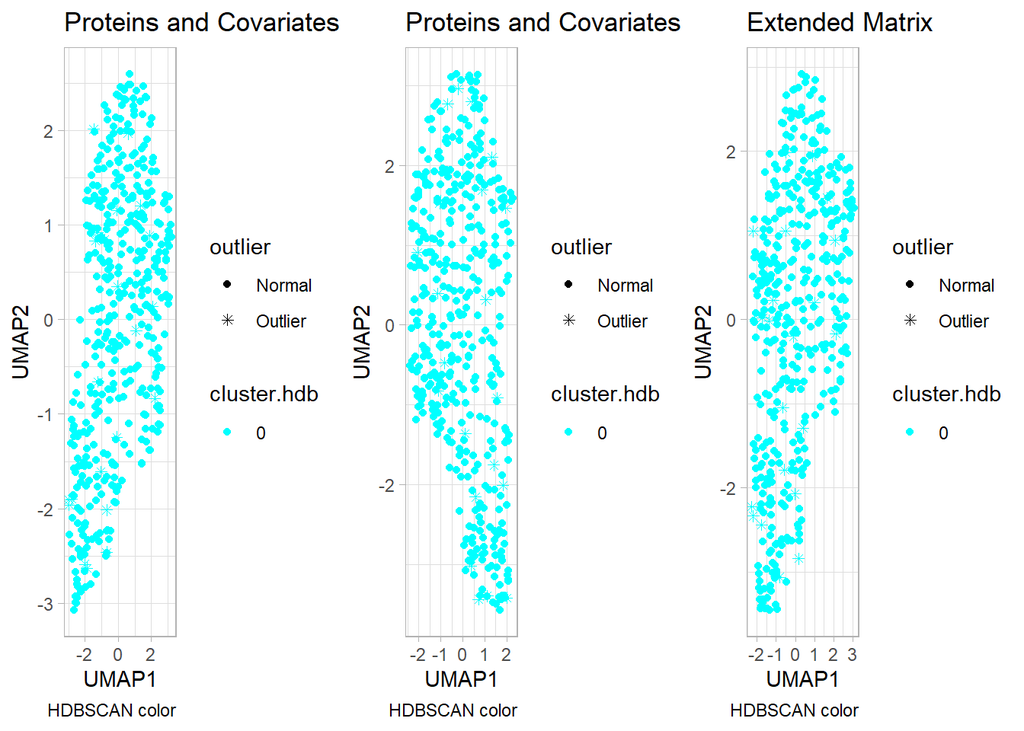

```r
hdb.data.umap <- ggplot(data.hdbscan, aes(X1, X2, col = cluster.hdb, shape = outlier )) +
  geom_point() +
  labs(title='Proteins and Covariates',
       caption= 'HDBSCAN color') +
  xlab('UMAP1') + ylab('UMAP2') +
  theme_light() +
  scale_shape_manual(values = c('Normal' = 19, 'Outlier' = 8)) +
  scale_color_manual(values = colors[1:length(levels(data.hdbscan$cluster.hdb))])

hdb.em.umap <- ggplot(em.hdbscan, aes(X1, X2, col = cluster.hdb, shape = outlier )) +
  geom_point() +
  labs(title='Extended Matrix',
       caption= 'HDBSCAN color') +
  xlab('UMAP1') + ylab('UMAP2') +
  theme_light() +
  scale_shape_manual(values = c('Normal' = 19, 'Outlier' = 8)) +
  scale_color_manual(values = colors[1:length(levels(em.hdbscan$cluster.hdb))])

hdb.proteins.umap <- ggplot(proteins.hdbscan, aes(X1, X2, col = cluster.hdb, shape = outlier )) +
  geom_point() +
  labs(title='Proteins and Covariates',
       caption= 'HDBSCAN color') +
  xlab('UMAP1') + ylab('UMAP2') +
  theme_light() +
  scale_shape_manual(values = c('Normal' = 19, 'Outlier' = 8)) +
  scale_color_manual(values = colors[1:length(levels(proteins.hdbscan$cluster.hdb))])

grid.arrange(hdb.data.umap, hdb.proteins.umap, hdb.em.umap, ncol = 3)
```

# Conclusiones

Este documento pretende facilitar el estudio de datos de proteómica de alta precisión usando tecnología Olink. Sin embargo las conclusiones han de extraerse de manera análoga comprobando los resultados obtenidos. Además también es altamente recomendado continuar con los análisis para encontrar más datos.